# EP11

# Librerías

```r
library(dplyr)
library(ggpubr)
library(car)
library(leaps)
library(caret)
library(pROC)
```

# Actividades:

1. Definir la semilla a utilizar, que corresponde a los primeros cinco dígitos del RUN del integrante de mayor edad del equipo.
2. Seleccionar una muestra de 100 personas, asegurando que la mitad tenga estado nutricional “sobrepeso” y la otra mitad “no sobrepeso”.
3. Usando las herramientas del paquete leaps, realizar una búsqueda exhaustiva para seleccionar entre dos y ocho predictores que ayuden a estimar la variable Peso (Weight), obviamente sin considerar las nuevas variables IMC ni EN, y luego utilizar las funciones del paquete caret para construir un modelo de regresión lineal múltiple con los predictores escogidos y evaluarlo usando bootstrapping.
4. Haciendo un poco de investigación sobre el paquete caret, en particular cómo hacer Recursive Feature Elimination (RFE), construir un modelo de regresión lineal múltiple para predecir la variable IMC que incluya entre 10 y 20 predictores, seleccionando el conjunto de variables que maximice R2 y que use cinco repeticiones de validación cruzada de cinco pliegues para evitar el sobreajuste (obviamente no se debe considerar las variables Peso, Estatura ni estado nutricional –Weight, Height, EN respectivamente).
5. Usando RFE, construir un modelo de regresión logística múltiple para la variable EN que incluya el conjunto de predictores, entre dos y seis, que entregue la mejor curva ROC y que utilice validación cruzada dejando uno fuera para evitar el sobreajuste (obviamente no se debe considerar las variables Peso, Estatura –Weight y Height respectivamente– ni IMC).
6. Pronunciarse sobre la confiabilidad y el poder predictivo de los modelos obtenidos.

Para esta experiencia, se optó por dividir las 100 observaciones en dos conjuntos: 70 para entrenamiento y 30 para prueba. Esta elección busca evaluar de manera más realista qué tan bien funcionan los modelos al enfrentarse a datos nuevos, es decir, su capacidad de generalización.

Si bien podríamos haber usado las 100 observaciones para ajustar los modelos, eso habría impedido comprobar su desempeño en datos no vistos. Además, considerando el tamaño del conjunto, la diferencia entre entrenar con 70 o 100 casos no es significativa, pero sí lo es contar con un conjunto independiente para validar los resultados de forma objetiva.

# Pregunta 1 y 2

```r
#Cargar Datos
set.seed(21130)

datos <- read.csv("EP09 Datos.csv", header = TRUE, sep = ";")

datos <- datos %>%
  mutate(across(everything(), ~ as.numeric(gsub(",", ".", .))))

# Calcular IMC
datos$IMC <- datos$Weight / ((datos$Height/100) ^2)

datos$EN <- ifelse(datos$IMC >= 23.2, "sobrepeso", "no sobrepeso")

# Separar por estado nutricional
sobrepeso <- datos %>% filter(EN == "sobrepeso")
no_sobrepeso <- datos %>% filter(EN == "no sobrepeso")

# Muestrear 50 de cada grupo para total 100
muestra_sobrepeso <- sample_n(sobrepeso, 50)
muestra_no_sobrepeso <- sample_n(no_sobrepeso, 50)

muestra_100 <- bind_rows(muestra_sobrepeso, muestra_no_sobrepeso)
muestra_100 <- muestra_100[sample(nrow(muestra_100)), ]

muestra_70 <- sample_n(muestra_100, 70)
muestra_30 <- anti_join(muestra_100, muestra_70)

# Verificar balance
table(muestra_100$EN)
```

```
##
## no sobrepeso    sobrepeso
##           50           50
```

```r
table(muestra_70$EN)
```

```
##
## no sobrepeso    sobrepeso
##           35           35
```

```r
table(muestra_30$EN)
```

```
##
## no sobrepeso    sobrepeso
##           15           15
```

## Pregunta 3 - Modelo RLM de predicción de Peso

Usando las herramientas del paquete leaps, se realiza una búsqueda exhaustiva de las mejores combinaciones de predictores, seleccionando de 2 a 8, dejando de lado las variables Weight, IMC, EN y Height.

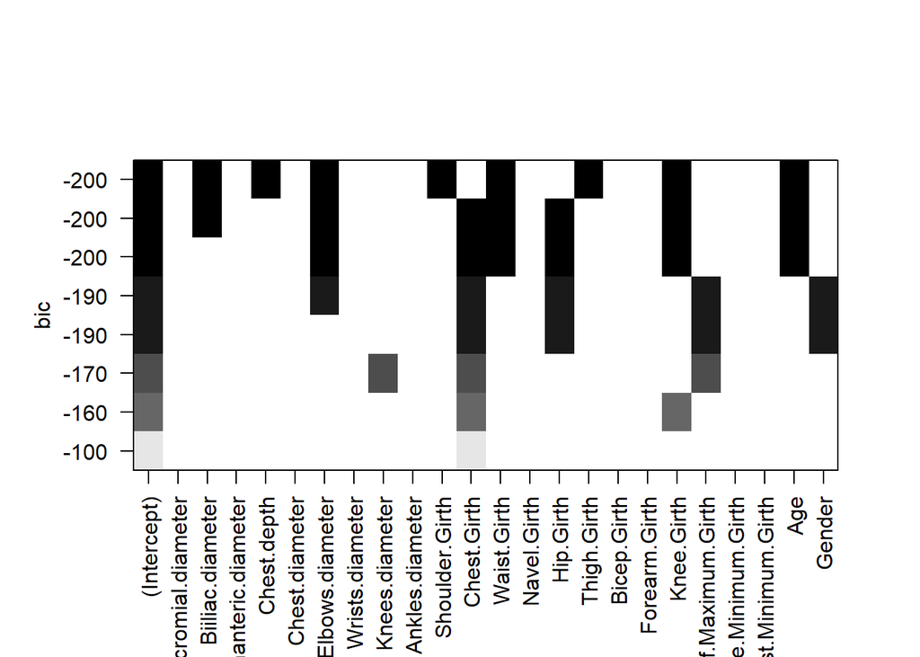

```r
#Cargar Datos
set.seed(21130)

datos_modelo_1 <- muestra_70 %>%
  select(-Weight, -IMC, -EN, -Height)  # Eliminamos variables a excluir

predictores_posibles <- colnames(datos_modelo_1)

combinaciones <- regsubsets(Weight ~ ., data = muestra_70[,c(predictores_posibles, "Weight")], nvmax = 8, method = "exhaustive")
plot(combinaciones)
```

```r
predictores_seleccionados <- summary(combinaciones)$which[which.max(summary(combinaciones)$adjr2), ]
predictores_seleccionados <- names(predictores_seleccionados[predictores_seleccionados == TRUE])
predictores_seleccionados <- setdiff(predictores_seleccionados, c("(Intercept)", "Weight"))

print(predictores_seleccionados)
```

```
## [1] "Biiliac.diameter" "Chest.depth"      "Elbows.diameter"  "Shoulder.Girth"
## [5] "Waist.Girth"      "Thigh.Girth"      "Knee.Girth"       "Age"
```

```r
muestra_rlm <- muestra_70[, c(predictores_seleccionados, "Weight")]

modelo_rlm <- lm(Weight ~ ., data = muestra_rlm)
```

Al realizar lo anterior, se observa que el conjunto de predictores con menor BIC son los que están más arriba de la matriz (-200). Esto indica que para el conjunto de datos analizado, estas ocho variables son las más relevantes para explicar la variable respuesta peso (Weight).

Una vez obtenido el modelo de regresión lineal múltiple (RLM) con las variables seleccionadas, se evaluará la generalidad del modelo RLM, verificando las condiciones de normalidad, homocedasticidad e independencia de los residuos, así como la presencia de valores atípicos e influyentes, añadiendose el test de multicolinealidad (VIF).

### Multicolinealidad

Dado que el modelo tiene muchos predictores, se evaluará la multicolinealidad del mismo, eliminando del modelo aquellos predictores que tengan un VIF mayor a 5, y se volverá a ajustar el modelo (en caso de que se requiera).

```r
vif(modelo_rlm)
```

```
## Biiliac.diameter      Chest.depth  Elbows.diameter   Shoulder.Girth
##         1.209026         2.626083         4.575507         4.286674
##      Waist.Girth      Thigh.Girth       Knee.Girth              Age
##         3.689734         1.671538         2.864178         1.546721
```

Como podemos notar, no hay ningún predictor con un VIF mayor a 5, por lo que el modelo se considera adecuado en términos de multicolinealidad.

### Bondad de ajuste del modelo RLM

```r
modelo_nulo <- lm(Weight ~ 1, data = muestra_rlm)
anova(modelo_nulo, modelo_rlm)
```

```
## Analysis of Variance Table
##
## Model 1: Weight ~ 1
## Model 2: Weight ~ Biiliac.diameter + Chest.depth + Elbows.diameter + Shoulder.Girth +
##     Waist.Girth + Thigh.Girth + Knee.Girth + Age
##   Res.Df     RSS Df Sum of Sq      F    Pr(>F)
## 1     69 10441.8
## 2     61   324.1  8     10118 238.03 < 2.2e-16 ***
## ---
## Signif. codes:  0 '***' 0.001 '**' 0.01 '*' 0.05 '.' 0.1 ' ' 1
```

Además, la reducción del RSS, evidencia una mejora sustancial en el ajuste del modelo, lo que se traduce en una menor variabilidad no explicada por los predictores. El estadístico F = 238.03 es elevado, reforzando la conclusión de que el modelo completo es significativamente superior al modelo sin predictores.

## Gráfico de Residuos

Gráfico de residuos:

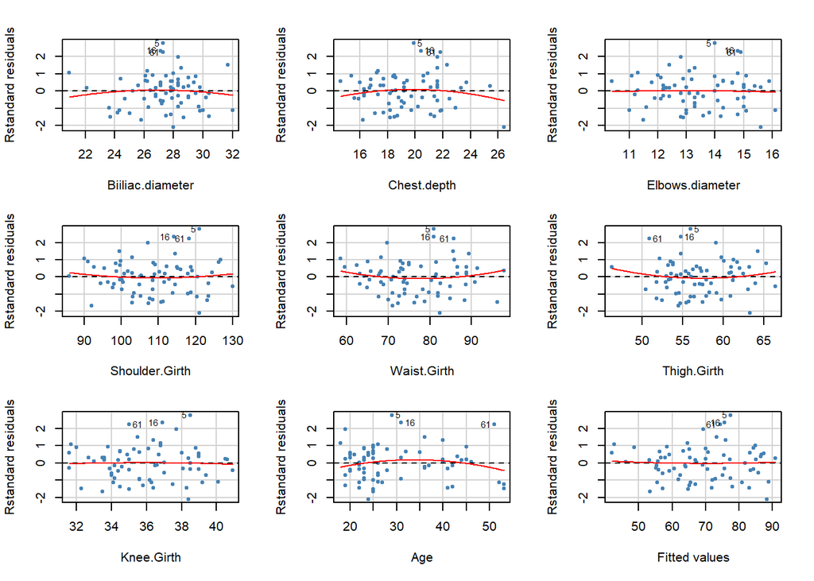

```
##                  Test stat Pr(>|Test stat|)
## Biiliac.diameter   -0.6658           0.5081
## Chest.depth        -0.9311           0.3556
## Elbows.diameter    -0.1519           0.8798
## Shoulder.Girth      0.4967           0.6212
## Waist.Girth         0.8987           0.3724
## Thigh.Girth         0.7325           0.4667
## Knee.Girth         -0.2049           0.8383
## Age                -1.0885           0.2807
## Tukey test          0.1885           0.8505
```

```r
residualPlots(
  modelo_rlm,
  type = "rstandard",
  id = list(method = "r", n = 3, cex = 0.7, location = "lr"),
  col = "steelblue",
  pch = 20,
  col.quad = "red"
)
```

Como se observa en el gráfico de residuos, la mayoría de los puntos están distribuidos aleatoriamente alrededor de cero, además de que no se observan patrones evidentes en los residuos. Sin embargo, hay algunos puntos que se desvían de la tendencia general, lo que podría indicar la presencia de valores atípicos o influencias en el modelo. Por otro lado, el p valor del test es mayor a 0.05, lo que indica que no se rechaza la hipótesis nula de la existencia de linealidad.

Se evalúa la normalidad de los residuos utilizando el gráfico Q-Q y la prueba de Shapiro-Wilk:

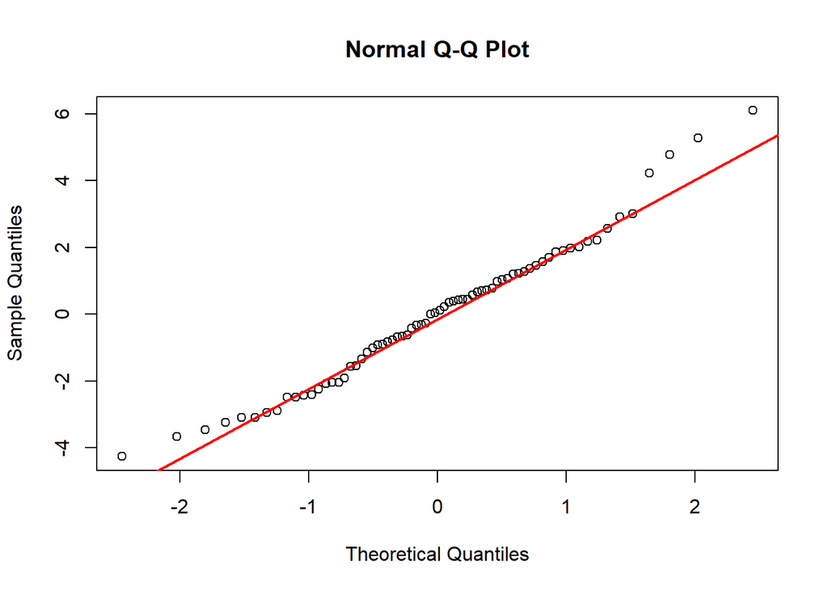

```r
residuos2 <- residuals(modelo_rlm)

qqnorm(residuos2)
qqline(residuos2, col = "red", lwd = 2)
```

```r
shapiro.test(modelo_rlm$residuals)
```

```
##
##  Shapiro-Wilk normality test
##
## data:  modelo_rlm$residuals
## W = 0.97917, p-value = 0.2944
```

Como resultado, se observa que los residuos siguen una distribución normal, ya que el p-valor del test de Shapiro-Wilk es mayor a 0.05. Además, al observar el gráfico Q-Q, se identifica que los residuos se distribuyen de manera aproximadamente normal, ya que los puntos se alinean a lo largo de la línea diagonal.

Para evaluar la homocedasticidad de los residuos y la independencia de los mismo, se utilizará los test de NCV y Durbin-Watson.

- Test homocedasticidad:

```r
set.seed(21130)

# También con los valores ajustados
ncvTest(modelo_rlm, ~ fitted(modelo_rlm))
```

```
## Non-constant Variance Score Test
## Variance formula: ~ fitted(modelo_rlm)
## Chisquare = 1.696178, Df = 1, p = 0.19279
```

- Test de independencia de residuos (Durbin-Watson):

```r
set.seed(21130)
durbinWatsonTest(modelo_rlm)
```

```
##  lag Autocorrelation D-W Statistic p-value
##    1      -0.1683311      2.304979   0.176
##  Alternative hypothesis: rho != 0
```

El test de homocedasticidad arrojó un p-valor de 0.19279, por lo que no se rechaza la hipótesis nula de homocedasticidad, concluyéndose que los residuos presentan varianza constante. Por otro lado, el test de Durbin-Watson entregó un estadístico de 2.305 y un p-valor de 0.176, lo que indica que no existe evidencia de autocorrelación en los errores. Por lo tanto, ambos resultados respaldan la validez del modelo estudiado.

Finalmente para este modelo se evalúa la presencia de valores atípicos e influyentes, utilizando el gráfico de influencia:

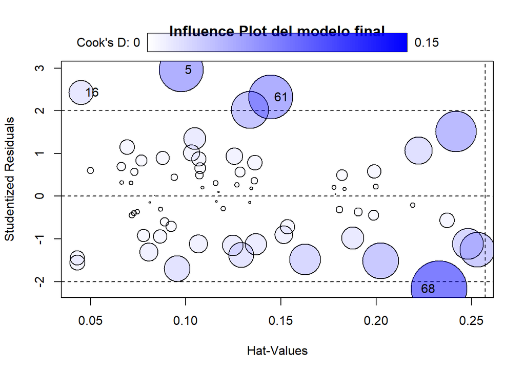

```
##      StudRes        Hat      CookD
## 5   2.957989 0.09758606 0.09328068
## 16  2.432831 0.04499184 0.02867012
## 61  2.322724 0.14455781 0.09449059
## 68 -2.169665 0.23300214 0.14979052
```

```r
# Gráfico de influencia (residuos estudentizados, leverage y distancia de Cook)
influencePlot(modelo_rlm,
              id = list(method = "r", n = 4),
              main = "Influence Plot del modelo final")
```

En el gráfico de influencia de valores atípicos, se identifican observaciones que podrían dar problemas e influir en el modelo. El gráfico de los componentes más los residuos estudentizados del modelo es:

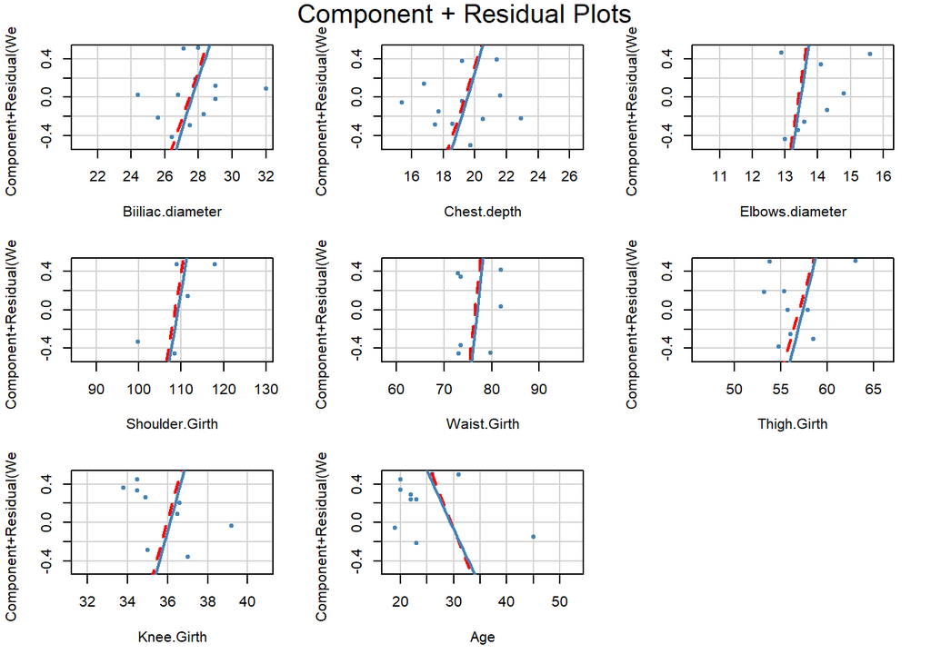

```r
crPlots(modelo_rlm,
        ylim = c(-0.5, 0.5),
        col = "steelblue",
        pch = 20,
        col.lines = c("red", "steelblue"),
        smooth = list(smoother = loessLine, span = 1),
        id = list(method = "r", n = 8, cex = 0.7, location = "lr"))
```

Luego, se decidió evaluar el impacto específico de dicha observación, la cual es la observación 68 con un CookD de 0.149, por lo que se elimina del modelo anterior para ver si su eliminación afecta significativamente el modelo:

```r
# Eliminar la observación 4 del dataset original que usaste para ajustar el modelo
muestra_rlm_sin_outlier <- muestra_rlm[-68, ]

# Volver a ajustar el modelo con el dataset sin la observación 4
modelo_rlm_sin_outlier <- lm(Weight ~ ., data = muestra_rlm_sin_outlier)

# Revisar resumen para comparar con el modelo original
summary(modelo_rlm_sin_outlier)
```

```
##
## Call:
## lm(formula = Weight ~ ., data = muestra_rlm_sin_outlier)
##
## Residuals:
##     Min      1Q  Median      3Q     Max
## -3.3964 -1.5252 -0.0039  1.4438  6.2373
##
## Coefficients:
##                   Estimate Std. Error t value Pr(>|t|)
## (Intercept)      -90.29570    5.70738 -15.821  < 2e-16 ***
## Biiliac.diameter   0.48906    0.14516   3.369 0.001322 **
## Chest.depth        0.68217    0.19708   3.461 0.000997 ***
## Elbows.diameter    2.26446    0.42758   5.296 1.77e-06 ***
## Shoulder.Girth     0.25830    0.05561   4.645 1.91e-05 ***
## Waist.Girth        0.42421    0.05796   7.319 7.14e-10 ***
## Thigh.Girth        0.36205    0.08710   4.157 0.000104 ***
## Knee.Girth         0.70889    0.19312   3.671 0.000516 ***
## Age               -0.14324    0.03469  -4.129 0.000114 ***
## ---
## Signif. codes:  0 '***' 0.001 '**' 0.01 '*' 0.05 '.' 0.1 ' ' 1
##
## Residual standard error: 2.238 on 60 degrees of freedom
## Multiple R-squared:  0.9706, Adjusted R-squared:  0.9666
## F-statistic: 247.3 on 8 and 60 DF,  p-value: < 2.2e-16
```

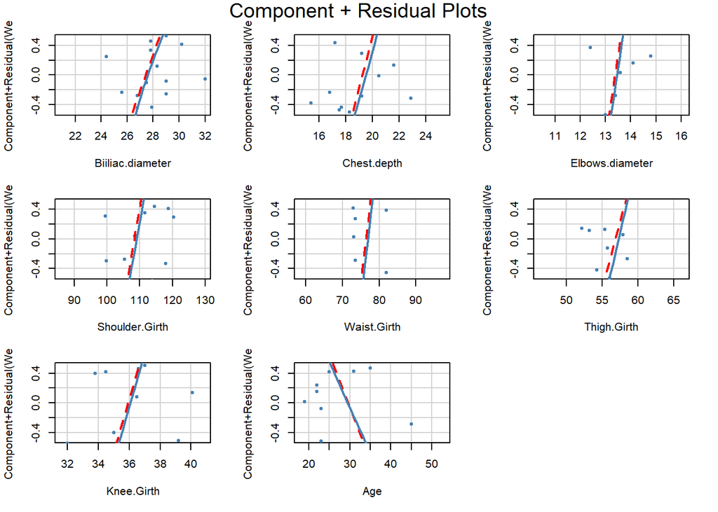

```r
crPlots(modelo_rlm_sin_outlier,
        ylim = c(-0.5, 0.5),
        col = "steelblue",
        pch = 20,
        col.lines = c("red", "steelblue"),
        smooth = list(smoother = loessLine, span = 1),
        id = list(method = "r", n = 8, cex = 0.7, location = "lr"))
```

Al eliminar dicha observación, se observa que el comportamiento general del modelo no cambia significativamente y tampoco se evidencia un patrón de apalancamiento relevante. Esto sugiere que, si bien la observación 68 tenía cierta influencia (según el gráfico de Cook’s Distance), el sacar esta observación del modelo, no altera al mismo.

Según los resultados, el modelo RLM obtenido puede ser considerado confiable, puesto que el modelo ha cumplido con las condiciones necesarias, y en casos donde no fue posible cumplir con alguna condición, se realizaron ajustes necesarios para corregirlo, aunque para este caso, no aplicó. Por lo tanto, el modelo RLM se considera adecuado para proseguir con la evaluación de su poder predictivo.

## Calidad Predictiva del modelo RLM del apartado 3)

Una vez obtenido el modelo de regresión lineal múltiple (RLM) con las variables seleccionadas, se procede a evaluarlo gracias a la función train(), usando bootstrapping con 50 repeticiones para evitar sobreajuste, definiendo una semilla para reproducibilidad.

```
##
## Error estimado para el modelo:
```

```
##        RMSE  Rsquared      MAE   Resample
## 1  2.157565 0.9792637 1.730705 Resample01
## 2  2.123229 0.9619842 1.699705 Resample02
## 3  2.675468 0.9437003 2.115368 Resample03
## 4  3.057155 0.9648654 2.449334 Resample04
## 5  2.597145 0.9635389 2.118970 Resample05
## 6  2.771927 0.9633939 2.241436 Resample06
## 7  2.941850 0.9638935 2.353537 Resample07
## 8  2.772210 0.9334201 2.078673 Resample08
## 9  2.603387 0.9509274 1.952918 Resample09
## 10 2.540755 0.9786971 1.947573 Resample10
## 11 3.030968 0.9385836 2.461550 Resample11
## 12 2.266314 0.9617418 1.845925 Resample12
## 13 2.472171 0.9683363 1.903933 Resample13
## 14 2.594239 0.9424532 2.109879 Resample14
```

[output cut: 36 more lines]

```
##   intercept     RMSE Rsquared      MAE    RMSESD RsquaredSD     MAESD
## 1      TRUE 2.613348 0.957794 2.092225 0.2788764  0.0137665 0.2348797
```

El modelo validado con bootstrap (50 repeticiones) mostró un bajo error promedio (RMSE = 2.61, MAE = 2.09) y un alto poder explicativo (R-squared = 0.958) del 95.8%. La baja variabilidad entre repeticiones confirma que el modelo es estable y generaliza bien, lo que respalda su capacidad predictiva sobre nuevos datos.

Ahora se procederá a evaluar el modelo con el conjunto de prueba (muestra_30) para verificar su desempeño en datos no vistos:

```
##
## Resultados del modelo de entrenamiento usando el conjunto de prueba:
```

```
##      RMSE  Rsquared       MAE
## 2.3932389 0.9627598 1.8361813
```

Los resultados obtenidos indican que el modelo logra mantener un nivel de error bajo, con valores de RMSE y MAE similares a los observados durante la validación con bootstrap. Asimismo, R-squared se mantiene elevado, lo que confirma que el modelo conserva un alto poder explicativo fuera de la muestra original.

Estos resultados respaldan la capacidad de generalización del modelo, demostrando que no solo se ajusta bien a los datos de entrenamiento, sino que también es capaz de realizar predicciones precisas en nuevos casos. Por lo tanto, se concluye que el modelo es adecuado tanto en términos de ajuste como de desempeño predictivo.

# Pregunta 4 - Modelo RLM de predicción de IMC

```r
set.seed(21130)

control_rfe <- rfeControl(
  functions = lmFuncs,
  method = "repeatedcv",
  number = 5,
  repeats = 5,
  verbose = FALSE
)

rfe_result <- rfe(
  x = datos_modelo_1,
  y = muestra_70$IMC,
  sizes = c(10:20),
  rfeControl = control_rfe,
  metric = "Rsquared"
)

predictores_imc <- predictors(rfe_result)

modelo_IMC <- lm(
  formula = as.formula(paste("IMC ~", paste(predictores_imc, collapse = " + "))),
  data = muestra_70
)

summary(modelo_IMC)
```

```
##
## Call:
## lm(formula = as.formula(paste("IMC ~", paste(predictores_imc,
##     collapse = " + "))), data = muestra_70)
##
## Residuals:
##     Min      1Q  Median      3Q     Max
## -3.0550 -0.5074  0.1071  0.5300  1.9569
##
## Coefficients:
##                          Estimate Std. Error t value Pr(>|t|)
## (Intercept)             -6.090709   3.756531  -1.621  0.11136
## Gender                  -2.273749   0.875386  -2.597  0.01237 *
## Wrist.Minimum.Girth     -0.735014   0.370123  -1.986  0.05266 .
## Forearm.Girth            0.668323   0.242051   2.761  0.00808 **
## Knees.diameter           0.610003   0.223779   2.726  0.00887 **
## Elbows.diameter         -0.449110   0.344059  -1.305  0.19788
## Wrists.diameter         -0.357833   0.374924  -0.954  0.34456
## Ankles.diameter         -0.278048   0.260328  -1.068  0.29072
## Calf.Maximum.Girth       0.307534   0.125590   2.449  0.01796 *
## Biiliac.diameter        -0.322859   0.101030  -3.196  0.00244 **
## Ankle.Minimum.Girth      0.140919   0.191503   0.736  0.46532
## Bitrochanteric.diameter  0.160036   0.129718   1.234  0.22319
## Chest.depth             -0.110741   0.109514  -1.011  0.31689
## Chest.diameter          -0.074179   0.124350  -0.597  0.55357
## Bicep.Girth              0.083940   0.119507   0.702  0.48576
## Chest.Girth              0.105990   0.047997   2.208  0.03194 *
## Knee.Girth               0.006166   0.142152   0.043  0.96558
## Biacromial.diameter      0.044603   0.095001   0.470  0.64079
## Waist.Girth              0.095879   0.044421   2.158  0.03582 *
## Thigh.Girth             -0.097126   0.063099  -1.539  0.13017
## Navel.Girth              0.056991   0.035814   1.591  0.11797
## ---
## Signif. codes:  0 '***' 0.001 '**' 0.01 '*' 0.05 '.' 0.1 ' ' 1
##
## Residual standard error: 1.083 on 49 degrees of freedom
## Multiple R-squared:  0.8934, Adjusted R-squared:  0.8499
## F-statistic: 20.53 on 20 and 49 DF,  p-value: < 2.2e-16
```

### Bondad de ajuste del modelo IMC

```r
modelo_nulo_imc <- lm(IMC ~ 1, data = muestra_70)
anova(modelo_nulo_imc, modelo_IMC, test = "LRT")
```

```
## Analysis of Variance Table
##
## Model 1: IMC ~ 1
## Model 2: IMC ~ Gender + Wrist.Minimum.Girth + Forearm.Girth + Knees.diameter +
##     Elbows.diameter + Wrists.diameter + Ankles.diameter + Calf.Maximum.Girth +
##     Biiliac.diameter + Ankle.Minimum.Girth + Bitrochanteric.diameter +
##     Chest.depth + Chest.diameter + Bicep.Girth + Chest.Girth +
##     Knee.Girth + Biacromial.diameter + Waist.Girth + Thigh.Girth +
##     Navel.Girth
##   Res.Df    RSS Df Sum of Sq  Pr(>Chi)
## 1     69 538.69
## 2     49  57.43 20    481.25 < 2.2e-16 ***
## ---
## Signif. codes:  0 '***' 0.001 '**' 0.01 '*' 0.05 '.' 0.1 ' ' 1
```

El test de razón de verosimilitud entre el modelo nulo y el modelo completo muestra una mejora significativa, lo que indica que el conjunto de variables contribuye de manera importante a la predicción del IMC. La disminución sustancial en la suma de cuadrados residual (de 538.69 a 57.43) refuerza la evidencia de que el modelo se ajusta bien a los datos y captura una proporción considerable de la variabilidad total del IMC. Por tanto, se concluye que el modelo presenta una buena bondad de ajuste global.

## Generalidad del modelo IMC

A continuación se realizará un análisis sobre la posible multicolinealidad de las variables del modelo, en caso de encontrar valores altos de VIF (superiores o iguales a 5) se descartarán del modelo:

```r
cat("\nValores VIF del modelo IMC:\n")
```

```
##
## Valores VIF del modelo IMC:
```

```r
vif(modelo_IMC)
```

```
##                  Gender     Wrist.Minimum.Girth           Forearm.Girth
##               11.432241               14.974063               31.426020
##          Knees.diameter         Elbows.diameter         Wrists.diameter
##                5.862192               12.853662                7.605082
##         Ankles.diameter      Calf.Maximum.Girth        Biiliac.diameter
##                6.348768                6.810185                2.513485
##     Ankle.Minimum.Girth Bitrochanteric.diameter             Chest.depth
##                4.809150                2.785451                4.101150
##          Chest.diameter             Bicep.Girth             Chest.Girth
##                5.817494               18.138046               13.091550
##              Knee.Girth     Biacromial.diameter             Waist.Girth
##                6.724777                4.995092                9.632256
##             Thigh.Girth             Navel.Girth
##                3.812937                5.715237
```

```r
modelo_IMC <- update(modelo_IMC, . ~ . - Forearm.Girth)
cat("\nVIF después de eliminar Forearm.Girth:\n")
```

```
##
## VIF después de eliminar Forearm.Girth:
```

```r
vif(modelo_IMC)
```

```
##                  Gender     Wrist.Minimum.Girth          Knees.diameter
##                9.558166               12.626769                5.733224
##         Elbows.diameter         Wrists.diameter         Ankles.diameter
##               12.785458                7.588719                6.333517
##      Calf.Maximum.Girth        Biiliac.diameter     Ankle.Minimum.Girth
##                6.644750                2.320458                4.701138
## Bitrochanteric.diameter             Chest.depth          Chest.diameter
##                2.616885                4.095413                5.767292
##             Bicep.Girth             Chest.Girth              Knee.Girth
##               11.791590               12.466711                6.646147
##     Biacromial.diameter             Waist.Girth             Thigh.Girth
##                4.636993                9.606661                3.811402
##             Navel.Girth
##                5.712722
```

```r
modelo_IMC <- update(modelo_IMC, . ~ . - Elbows.diameter)
cat("\nVIF después de eliminar Elbows.diameter:\n")
```

```
##
## VIF después de eliminar Elbows.diameter:
```

```r
vif(modelo_IMC)
```

```
##                  Gender     Wrist.Minimum.Girth          Knees.diameter
##                9.557945               12.549298                5.665363
##         Wrists.diameter         Ankles.diameter      Calf.Maximum.Girth
##                5.587582                6.041139                6.639385
##        Biiliac.diameter     Ankle.Minimum.Girth Bitrochanteric.diameter
##                2.309339                4.563723                2.584132
##             Chest.depth          Chest.diameter             Bicep.Girth
##                3.983593                5.655995               10.539449
##             Chest.Girth              Knee.Girth     Biacromial.diameter
##               12.437062                6.489991                4.622198
##             Waist.Girth             Thigh.Girth             Navel.Girth
##                9.415731                3.489756                5.626140
```

```r
modelo_IMC <- update(modelo_IMC, . ~ . - Wrist.Minimum.Girth)
cat("\nVIF después de eliminar Wrist.Minimum.Girth:\n")
```

```
##
## VIF después de eliminar Wrist.Minimum.Girth:
```

```r
vif(modelo_IMC)
```

```
##                  Gender          Knees.diameter         Wrists.diameter
##                9.339880                4.885022                5.225622
##         Ankles.diameter      Calf.Maximum.Girth        Biiliac.diameter
##                6.020923                6.537314                2.309321
##     Ankle.Minimum.Girth Bitrochanteric.diameter             Chest.depth
##                4.220221                2.569330                3.952787
##          Chest.diameter             Bicep.Girth             Chest.Girth
##                5.608449                8.543989               12.434956
##              Knee.Girth     Biacromial.diameter             Waist.Girth
##                6.135867                4.594002                9.165633
##             Thigh.Girth             Navel.Girth
##                3.488416                5.526406
```

```r
modelo_IMC <- update(modelo_IMC, . ~ . - Chest.Girth)
cat("\nVIF después de eliminar Chest.Girth:\n")
```

```
##
## VIF después de eliminar Chest.Girth:
```

```r
vif(modelo_IMC)
```

```
##                  Gender          Knees.diameter         Wrists.diameter
##                9.264105                4.861530                5.149296
##         Ankles.diameter      Calf.Maximum.Girth        Biiliac.diameter
##                5.969953                6.393983                2.305080
##     Ankle.Minimum.Girth Bitrochanteric.diameter             Chest.depth
##                4.089234                2.542457                3.135019
##          Chest.diameter             Bicep.Girth              Knee.Girth
##                4.738820                5.644091                6.110775
##     Biacromial.diameter             Waist.Girth             Thigh.Girth
##                4.590574                8.581427                3.488065
##             Navel.Girth
##                5.490234
```

```r
modelo_IMC <- update(modelo_IMC, . ~ . - Gender)
cat("\nVIF después de eliminar Gender:\n")
```

```
##
## VIF después de eliminar Gender:
```

```r
vif(modelo_IMC)
```

```
##          Knees.diameter         Wrists.diameter         Ankles.diameter
##                4.790329                5.117436                5.354296
##      Calf.Maximum.Girth        Biiliac.diameter     Ankle.Minimum.Girth
##                6.040056                2.293676                3.985129
## Bitrochanteric.diameter             Chest.depth          Chest.diameter
##                2.504197                3.084676                4.737765
##             Bicep.Girth              Knee.Girth     Biacromial.diameter
##                4.488404                6.066612                4.214138
##             Waist.Girth             Thigh.Girth             Navel.Girth
##                6.158057                3.209880                3.568838
```

```r
modelo_IMC <- update(modelo_IMC, . ~ . - Waist.Girth)
cat("\nVIF después de eliminar Waist.Girth:\n")
```

```
##
## VIF después de eliminar Waist.Girth:
```

```r
vif(modelo_IMC)
```

```
##          Knees.diameter         Wrists.diameter         Ankles.diameter
##                4.789796                5.098999                5.353538
##      Calf.Maximum.Girth        Biiliac.diameter     Ankle.Minimum.Girth
##                5.640354                2.217150                3.974534
## Bitrochanteric.diameter             Chest.depth          Chest.diameter
##                2.432257                3.045813                4.011065
##             Bicep.Girth              Knee.Girth     Biacromial.diameter
##                4.162117                6.055032                4.155426
##             Thigh.Girth             Navel.Girth
##                2.721854                2.214357
```

```r
modelo_IMC <- update(modelo_IMC, . ~ . - Knee.Girth)
cat("\nVIF después de eliminar Knee.Girth:\n")
```

```
##
## VIF después de eliminar Knee.Girth:
```

```r
vif(modelo_IMC)
```

```
##          Knees.diameter         Wrists.diameter         Ankles.diameter
##                4.497979                4.830383                5.349531
##      Calf.Maximum.Girth        Biiliac.diameter     Ankle.Minimum.Girth
##                4.505623                2.214152                3.672060
## Bitrochanteric.diameter             Chest.depth          Chest.diameter
##                2.425428                2.998004                3.927067
##             Bicep.Girth     Biacromial.diameter             Thigh.Girth
##                3.624935                4.136231                2.684884
##             Navel.Girth
##                2.198592
```

```r
modelo_IMC <- update(modelo_IMC, . ~ . - Ankles.diameter)
cat("\nVIF después de eliminar Ankles.diameter:\n")
```

```
##
## VIF después de eliminar Ankles.diameter:
```

```r
vif(modelo_IMC)
```

```
##          Knees.diameter         Wrists.diameter      Calf.Maximum.Girth
##                3.797231                4.086108                4.159996
##        Biiliac.diameter     Ankle.Minimum.Girth Bitrochanteric.diameter
##                2.158491                3.114086                2.412084
##             Chest.depth          Chest.diameter             Bicep.Girth
##                2.937756                3.609948                3.620431
##     Biacromial.diameter             Thigh.Girth             Navel.Girth
##                4.134998                2.682419                2.172311
```

Como resultado, gracias a la eliminación de variables “problemáticas” en cuanto sus valores VIF, se obtuvo un modelo moderado, lo que indica que no hay problemas de multicolinealidad significativos entre las variables seleccionadas.

Ahora se realizarán diversos gráficos analizando los residuos del modelo:

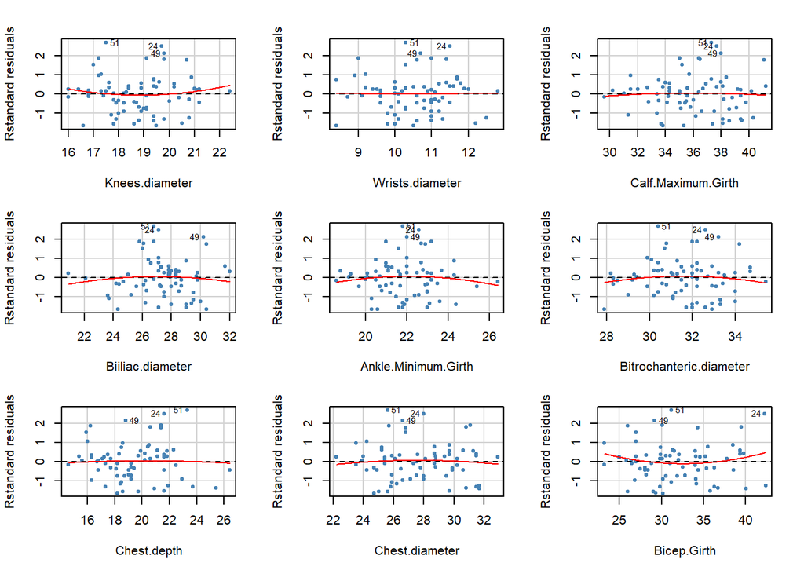

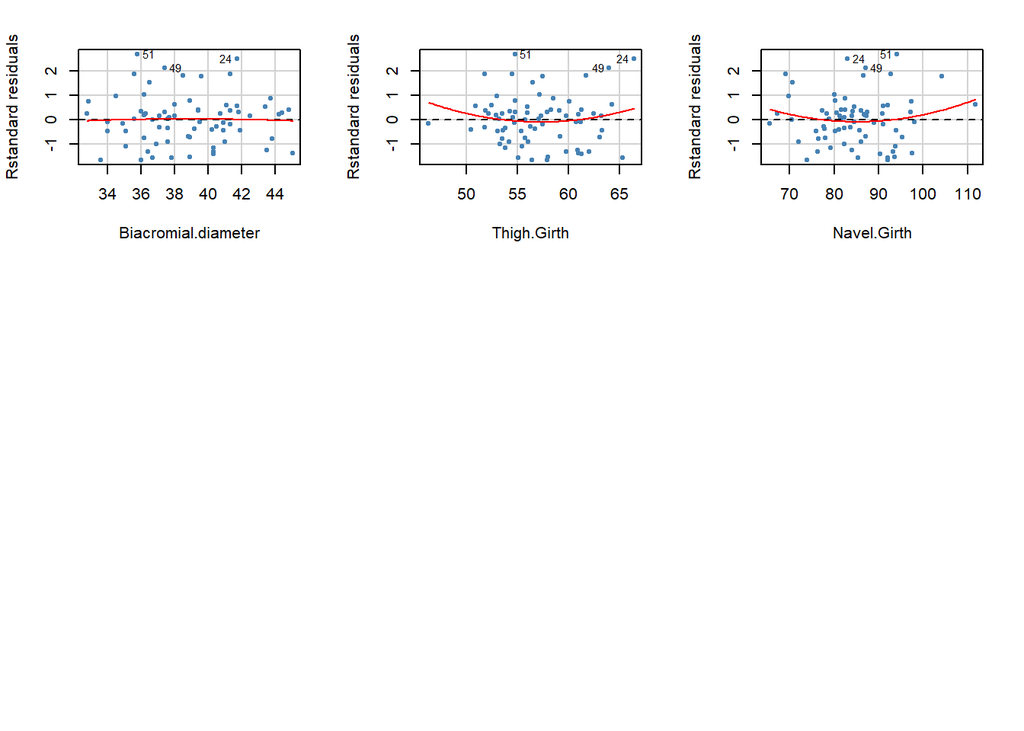

```
##                         Test stat Pr(>|Test stat|)
## Knees.diameter             0.8197           0.4159
## Wrists.diameter            0.0861           0.9317
## Calf.Maximum.Girth        -0.2916           0.7716
## Biiliac.diameter          -0.6073           0.5461
## Ankle.Minimum.Girth       -0.6061           0.5469
## Bitrochanteric.diameter   -0.6778           0.5007
## Chest.depth               -0.1552           0.8772
## Chest.diameter            -0.3329           0.7404
## Bicep.Girth                1.2837           0.2045
## Biacromial.diameter       -0.1392           0.8898
## Thigh.Girth                1.0433           0.3013
## Navel.Girth                1.3173           0.1931
```

```r
residualPlots(
  modelo_IMC,
  type = "rstandard",
  id = list(method = "r", n = 3, cex = 0.7, location = "lr"),
  col = "steelblue",
  pch = 20,
  col.quad = "red",fitted = FALSE
)
```

De estos gráficos es posible observar que existe una relacion aparentemente lineal,respaldado por los p-valores obtenidos en cada variable, los cuales son mayores al nivel de significancia (0.05), por lo que no es posible rechazar la hipótesis nula de linealidad.

Para evaluar la normalidad de los residuos, se utilizará el gráfico Q-Q y la prueba de Shapiro-Wilk:

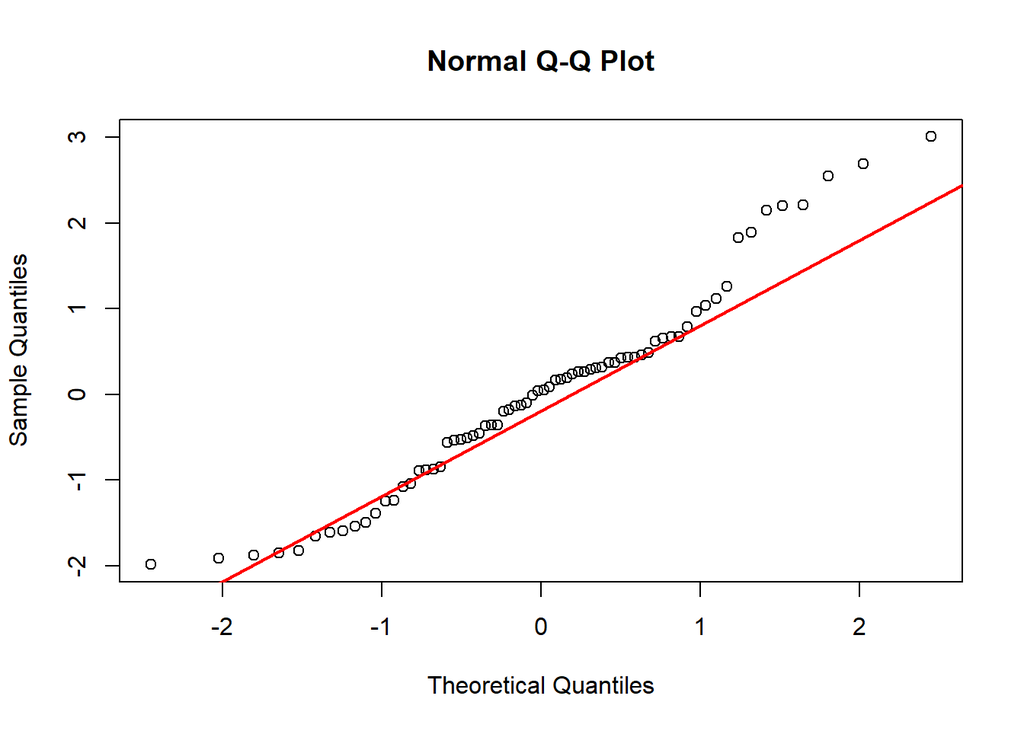

```r
residuos3 <- residuals(modelo_IMC)

qqnorm(residuos3)
qqline(residuos3, col = "red", lwd = 2)
```

```r
shapiro.test(modelo_IMC$residuals)
```

```
##
##  Shapiro-Wilk normality test
##
## data:  modelo_IMC$residuals
## W = 0.96266, p-value = 0.03519
```

Como resultado, se observa como los residuos no siguen una distribución normal, ya que el p-valor del test de Shapiro-Wilk es menor a 0.05, lo que indica que se rechaza la hipótesis nula de normalidad de los residuos. No obsatne, se procederá a comprobar el modelo con las demás condiciones de igual forma, para comprobar si el modelo es válido en otros aspectos.

Siguiendo con el test de independencia de los residuos, se utilizará el test de Durbin-Watson para comprobar esta condición:

```r
set.seed(21130)
durbinWatsonTest(modelo_IMC)
```

```
##  lag Autocorrelation D-W Statistic p-value
##    1      0.03693187      1.909927   0.728
##  Alternative hypothesis: rho != 0
```

A partir de estos resultados se puede concluir que no hay evidencia de autocorrelación entre los residuos del modelo, ya que el p-valor es superior al nivel de significancia (0.05), por ende, no se rechaza la hipótesis nula de independencia de los residuos.

Para analizar la precencia de valores atípicos, se utilizará el gráfico de influencia:

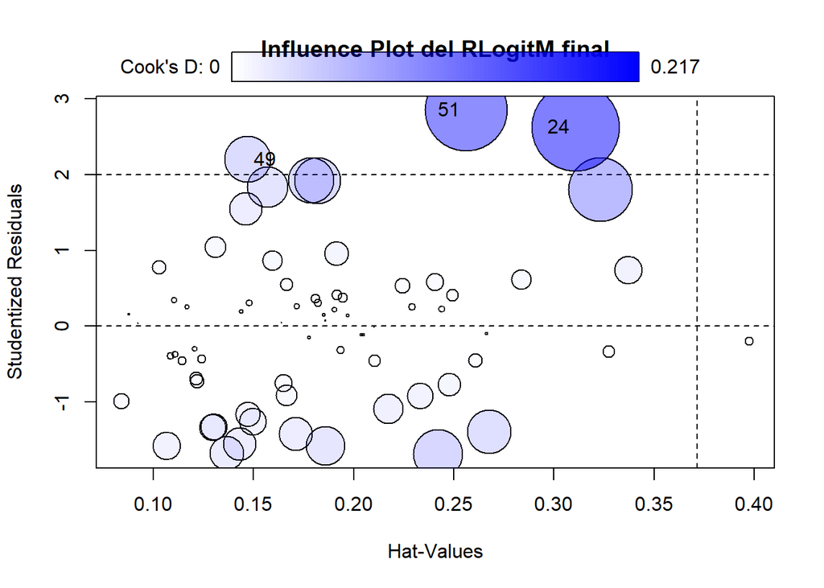

```
##     StudRes       Hat      CookD
## 51 2.852641 0.2559742 0.19139096
## 24 2.625189 0.3107786 0.21664678
## 49 2.201066 0.1472656 0.06029235
```

```r
influencePlot(modelo_IMC,
              id = list(method = "r", n = 3),
              main = "Influence Plot del RLogitM final")
```

Al realizar esta prueba se encontró un valor atípico con un CookD de 0.21, el cual es el caso 24, que se encuentra alejado del resto de los puntos, por lo cual, se procede a eliminarlo del modelo para ver si su eliminación afecta significativamente el modelo:

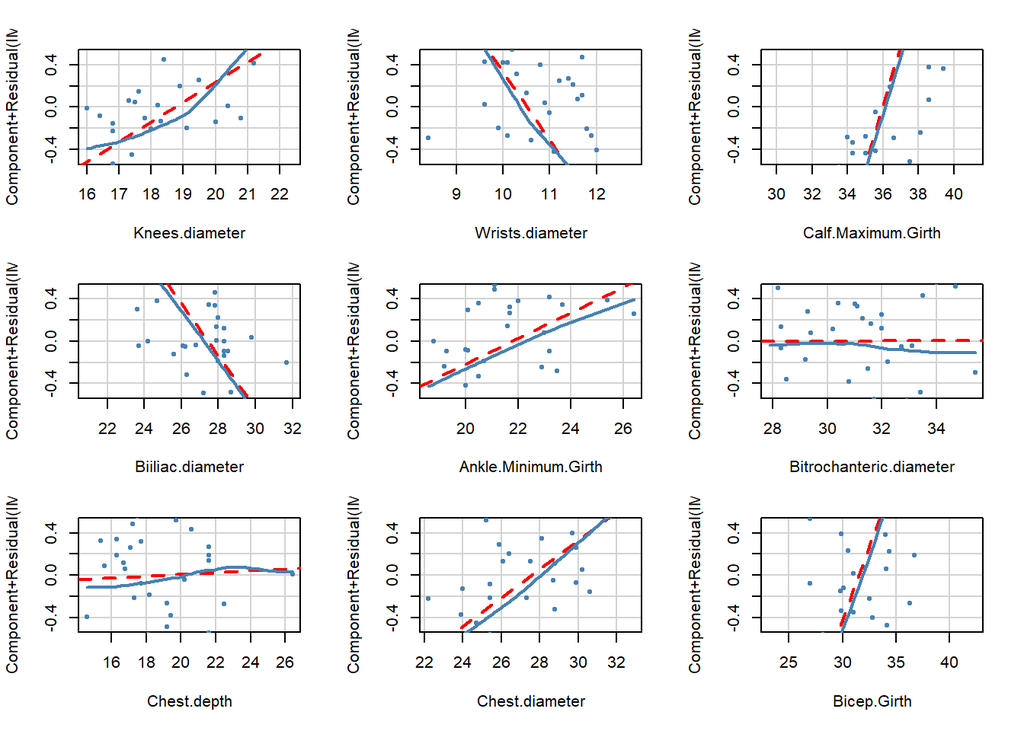

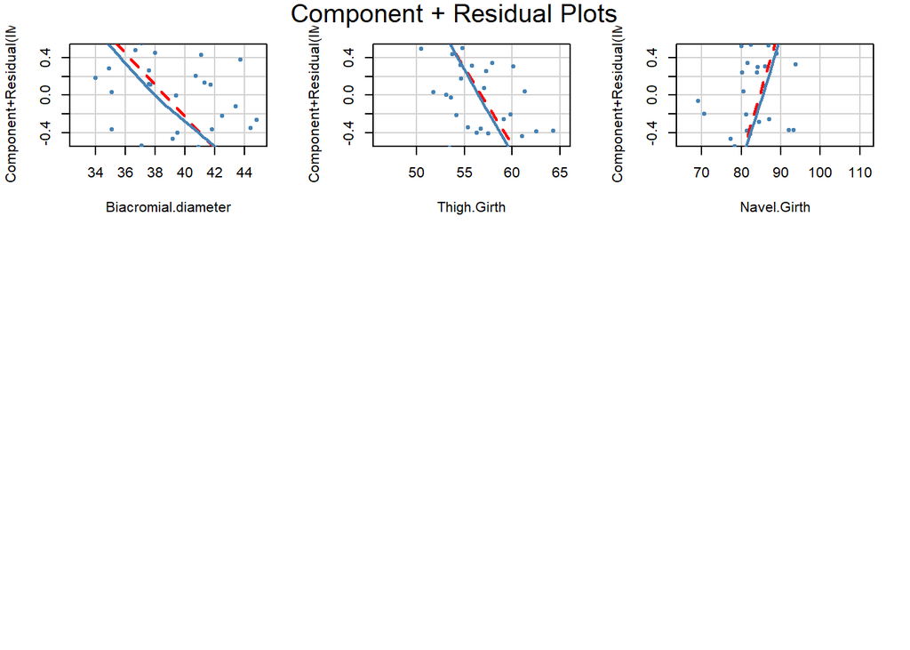

```r
muestra_imc <- muestra_70[, c(predictores_imc, "IMC")]


muestra_imc_sin_outlier <- muestra_imc[-24, ]

# Vector de variables a eliminar
vars_a_eliminar <- c("Forearm.Girth", "Elbows.diameter", "Wrist.Minimum.Girth",
                     "Chest.Girth", "Gender", "Waist.Girth", "Knee.Girth", "Ankles.diameter")

# Nuevos predictores excluyendo las variables eliminadas
predictores_filtrados <- setdiff(predictores_imc, vars_a_eliminar)

# Modelo sin outliers y sin las variables eliminadas
modelo_imc_sin_outlier_final <- lm(
  formula = as.formula(paste("IMC ~", paste(predictores_filtrados, collapse = " + "))),
  data = muestra_imc_sin_outlier
)

crPlots(modelo_imc_sin_outlier_final,
        ylim = c(-0.5, 0.5),
        col = "steelblue",
        pch = 20,
        col.lines = c("red", "steelblue"),
        smooth = list(smoother = loessLine, span = 1),
        id = list(method = "r", n = 8, cex = 0.7, location = "lr"))
```

En comparación con el modelo anterior:

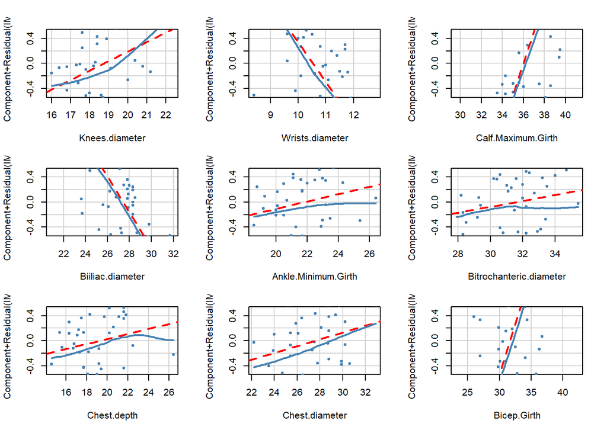

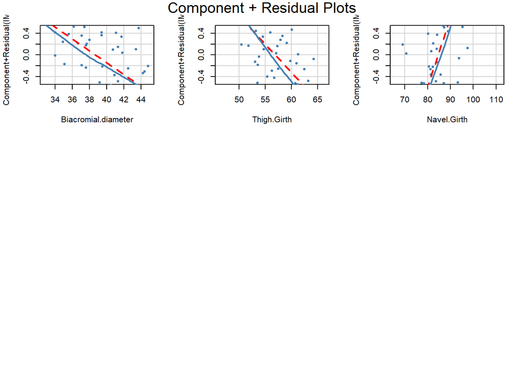

```r
crPlots(modelo_IMC,
        ylim = c(-0.5, 0.5),
        col = "steelblue",
        pch = 20,
        col.lines = c("red", "steelblue"),
        smooth = list(smoother = loessLine, span = 1),
        id = list(method = "r", n = 8, cex = 0.7, location = "lr"))
```

Al comparar ambos gráficos se observa un cambio notorio en la distribución de los residuos, lo que sugiere que la eliminación del valor atípico ha mejorado la homogeneidad de los residuos. A continuación se verifica la condición de normalidad de residuos que fallaba con anterioridad:

```r
shapiro.test(modelo_imc_sin_outlier_final$residuals)
```

```
##
##  Shapiro-Wilk normality test
##
## data:  modelo_imc_sin_outlier_final$residuals
## W = 0.97911, p-value = 0.3013
```

Como resultado es posible apreciar como los residuos ahora siguen una distribución normal, ya que el p-valor del test de Shapiro-Wilk es mayor a 0.05, por lo que no se rechaza la hipótesis nula de normalidad de los residuos. Por lo tanto, se concluye que este nuevo modelo es más adecuado que el anterior, ya que cumple con las condiciones de normalidad.

Sin embargo, se debe considerar que la extracción de un valor atípico puede alterar la composición del modelo, por lo tanto, para esta experiencia se utilizará el modelo con el valor atípico, ya que, además, puede ser considerado como un caso real.

### Desempeño modelo IMC

A continuacion, se evaluará el poder predictivo del modelo de regresión lineal múltiple (RLM) ajustado para predecir el IMC, utilizando la función `train()` del paquete `caret` con validación cruzada por bootstrapping (100 repeticiones) para evitar sobreajuste:

```r
datos_train_imc <- muestra_70[, c(predictores_imc, "IMC")]

set.seed(21130)

control_imc <- trainControl(
  method = "boot",
  number = 100
)

modelo_cv_imc <- train(
  IMC ~ .,
  data = datos_train_imc,
  method = "lm",
  trControl = control_imc
)

modelo_cv_finalModel <- modelo_cv_imc[["finalModel"]]
summary(modelo_cv_finalModel)
```

```
##
## Call:
## lm(formula = .outcome ~ ., data = dat)
##
## Residuals:
##     Min      1Q  Median      3Q     Max
## -3.0550 -0.5074  0.1071  0.5300  1.9569
##
## Coefficients:
##                          Estimate Std. Error t value Pr(>|t|)
## (Intercept)             -6.090709   3.756531  -1.621  0.11136
## Gender                  -2.273749   0.875386  -2.597  0.01237 *
## Wrist.Minimum.Girth     -0.735014   0.370123  -1.986  0.05266 .
## Forearm.Girth            0.668323   0.242051   2.761  0.00808 **
## Knees.diameter           0.610003   0.223779   2.726  0.00887 **
## Elbows.diameter         -0.449110   0.344059  -1.305  0.19788
## Wrists.diameter         -0.357833   0.374924  -0.954  0.34456
## Ankles.diameter         -0.278048   0.260328  -1.068  0.29072
## Calf.Maximum.Girth       0.307534   0.125590   2.449  0.01796 *
## Biiliac.diameter        -0.322859   0.101030  -3.196  0.00244 **
## Ankle.Minimum.Girth      0.140919   0.191503   0.736  0.46532
## Bitrochanteric.diameter  0.160036   0.129718   1.234  0.22319
## Chest.depth             -0.110741   0.109514  -1.011  0.31689
## Chest.diameter          -0.074179   0.124350  -0.597  0.55357
## Bicep.Girth              0.083940   0.119507   0.702  0.48576
## Chest.Girth              0.105990   0.047997   2.208  0.03194 *
## Knee.Girth               0.006166   0.142152   0.043  0.96558
## Biacromial.diameter      0.044603   0.095001   0.470  0.64079
## Waist.Girth              0.095879   0.044421   2.158  0.03582 *
## Thigh.Girth             -0.097126   0.063099  -1.539  0.13017
## Navel.Girth              0.056991   0.035814   1.591  0.11797
## ---
## Signif. codes:  0 '***' 0.001 '**' 0.01 '*' 0.05 '.' 0.1 ' ' 1
##
## Residual standard error: 1.083 on 49 degrees of freedom
## Multiple R-squared:  0.8934, Adjusted R-squared:  0.8499
## F-statistic: 20.53 on 20 and 49 DF,  p-value: < 2.2e-16
```

```r
cat("\nError estimado para el modelo:\n")
```

```
##
## Error estimado para el modelo:
```

```r
print(modelo_cv_imc[["resample"]])
```

```
##         RMSE  Rsquared       MAE    Resample
## 1   1.001474 0.9022633 0.8231062 Resample001
## 2   1.708051 0.7064149 1.2944576 Resample002
## 3   1.539427 0.7289807 1.1760664 Resample003
## 4   1.465711 0.8084848 1.2463692 Resample004
## 5   1.508168 0.7872159 1.1956640 Resample005
## 6   1.469334 0.7717890 1.2336435 Resample006
## 7   1.381911 0.8119831 1.1759063 Resample007
## 8   1.602068 0.5981657 1.2955560 Resample008
## 9   1.388087 0.7021773 1.1313638 Resample009
## 10  1.166869 0.8457537 0.9109648 Resample010
## 11  1.607664 0.5893991 1.2928540 Resample011
## 12  1.519940 0.6647228 1.1959019 Resample012
## 13  1.636218 0.7253818 1.3617148 Resample013
## 14  1.338272 0.6950891 0.9589708 Resample014
```

[output cut: 86 more lines]

```r
print(modelo_cv_imc[["results"]])
```

```
##   intercept     RMSE  Rsquared      MAE   RMSESD RsquaredSD     MAESD
## 1      TRUE 1.502485 0.7374109 1.189726 0.228765 0.08825571 0.1893006
```

```r
predicciones_rlm <- predict(modelo_cv_finalModel, newdata = muestra_30)

resultados_rlm <- postResample(pred = predicciones_rlm, obs = muestra_30$IMC)

print(resultados_rlm)
```

```
##     RMSE Rsquared      MAE
## 1.386068 0.766755 1.131752
```

El modelo de regresión lineal ajustado para predecir el IMC mostró un buen desempeño tanto en el conjunto de entrenamiento como en el conjunto de prueba externa. Durante el entrenamiento, mediante bootstrapping (100 repeticiones), se obtuvo un RMSE promedio de 1.502 y un R cuadrado de 0.737, con baja desviación. Al ser evaluado sobre datos no utilizados en la construcción del modelo, se observaron mejoras leves en todas las métricas: el RMSE se redujo a 1.386, el MAE a 1.132 y el R cuadrado aumentó a 0.766, por lo cual, se tiene que el modelo actual generaliza de forma aceptable a datos no vistos.

# Pregunta 5 - Modelo de Regresión Logística de predicción de Estado Nutricional

```r
set.seed(21130)


datos_modelo_3 <- muestra_70 %>%
  select(-Weight, -IMC, -Height) %>%
  mutate(EN = factor(EN, levels = c("no sobrepeso", "sobrepeso")))


control_rfe <- rfeControl(
  functions = lrFuncs,
  method = "LOOCV",
  verbose = FALSE,
  returnResamp = "final"
)

names(datos_modelo_3 %>% select(-EN))
```

```
##  [1] "Biacromial.diameter"     "Biiliac.diameter"
##  [3] "Bitrochanteric.diameter" "Chest.depth"
##  [5] "Chest.diameter"          "Elbows.diameter"
##  [7] "Wrists.diameter"         "Knees.diameter"
##  [9] "Ankles.diameter"         "Shoulder.Girth"
## [11] "Chest.Girth"             "Waist.Girth"
## [13] "Navel.Girth"             "Hip.Girth"
## [15] "Thigh.Girth"             "Bicep.Girth"
## [17] "Forearm.Girth"           "Knee.Girth"
## [19] "Calf.Maximum.Girth"      "Ankle.Minimum.Girth"
## [21] "Wrist.Minimum.Girth"     "Age"
## [23] "Gender"
```

```r
rfe_RLogitM <- suppressWarnings(rfe(
  x = datos_modelo_3 %>% select(-EN),
  y = datos_modelo_3$EN,
  sizes = 2:6,
  rfeControl = control_rfe,
  metric = "ROC"
))


print(rfe_RLogitM)
```

```
##
## Recursive feature selection
##
## Outer resampling method: Leave-One-Out Cross-Validation
##
## Resampling performance over subset size:
##
##  Variables Accuracy  Kappa Selected
##          2   0.8143 0.6286
##          3   0.8571 0.7143
##          4   0.8286 0.6571
##          5   0.8857 0.7714        *
##          6   0.8429 0.6857
##         23   0.7286 0.4571
##
## The top 5 variables (out of 5):
##    Chest.diameter, Ankle.Minimum.Girth, Shoulder.Girth, Forearm.Girth, Ankles.diameter
```

```r
predictores_log <- predictors(rfe_RLogitM)
print(predictores_log)
```

```
## [1] "Chest.diameter"      "Ankle.Minimum.Girth" "Shoulder.Girth"
## [4] "Forearm.Girth"       "Ankles.diameter"
```

```r
modelo_EN <- glm(
  formula = as.formula(paste("EN ~", paste(predictores_log, collapse = " + "))),
  data = datos_modelo_3,
  family = binomial()
)

# Multicolinealidad
print(vif(modelo_EN))
```

```
##      Chest.diameter Ankle.Minimum.Girth      Shoulder.Girth       Forearm.Girth
##            3.062946            1.466633            5.785683            5.011108
##     Ankles.diameter
##            2.688485
```

```r
modelo_EN <- update(modelo_EN, . ~ . - Shoulder.Girth)
print(vif(modelo_EN))
```

```
##      Chest.diameter Ankle.Minimum.Girth       Forearm.Girth     Ankles.diameter
##            1.577552            1.457626            2.260531            2.437494
```

```r
predictores_log <- predictors(modelo_EN)
```

Se eliminó el predictor “Shoulder.Girth” debido a que su valor de VIF era mayor a 5, lo que indica una alta multicolinealidad. Al ser eliminado, los valores VIF de los demás predictores se redujeron a valores aceptables, por lo que se decidió mantener el modelo sin este predictor.

### Bondad de Ajuste

```r
# Bondad de ajuste
ajuste <- anova(modelo_EN, test = "LRT")

cat("\nBondad de ajuste del modelo de predicción para EN:\n")
```

```
##
## Bondad de ajuste del modelo de predicción para EN:
```

```r
print(ajuste)
```

```
## Analysis of Deviance Table
##
## Model: binomial, link: logit
##
## Response: EN
##
## Terms added sequentially (first to last)
##
##
##                     Df Deviance Resid. Df Resid. Dev  Pr(>Chi)
## NULL                                   69     97.041
## Chest.diameter       1   33.825        68     63.216 6.031e-09 ***
## Ankle.Minimum.Girth  1    7.339        67     55.877  0.006747 **
## Forearm.Girth        1    2.436        66     53.441  0.118571
## Ankles.diameter      1    0.659        65     52.782  0.416962
## ---
## Signif. codes:  0 '***' 0.001 '**' 0.01 '*' 0.05 '.' 0.1 ' ' 1
```

Es posible observar que el modelo disminuye su devianza residual al agregar predictores, lo que indica una mejora en el ajuste del modelo. Además, dos variables presentan p-values menores a 0.05, indicando su significancia en el modelo. Los 2 predictores que no son significativos son “Forearm.Girth” y “Ankles.diameter”, pero no se considera justificado el eliminarlos en esta etapa de la evaluación puesto que la función rfe no los eliminó.

### Gráfico de residuos

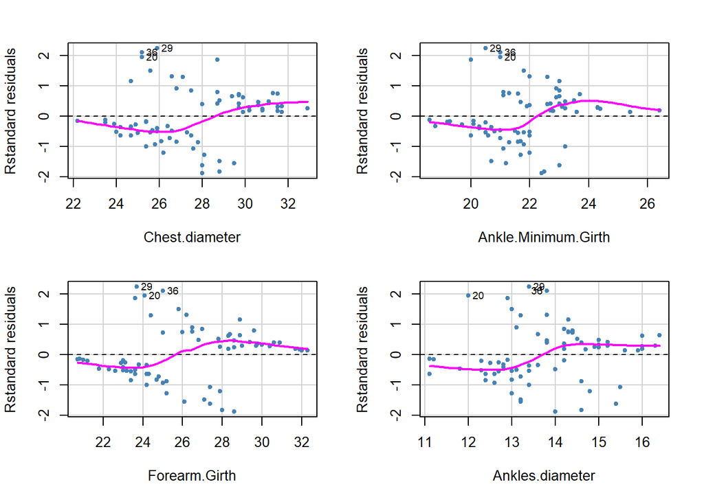

```
##                     Test stat Pr(>|Test stat|)
## Chest.diameter         1.7665           0.1838
## Ankle.Minimum.Girth    0.7960           0.3723
## Forearm.Girth          0.0720           0.7885
## Ankles.diameter        0.1184           0.7308
```

```r
# Gráfico de residuos
residualPlots(
  modelo_EN,
  type = "rstandard",
  id = list(method = "r", n = 3, cex = 0.7, location = "lr"),
  col = "steelblue",
  pch = 20,
  col.quad = "red",fitted = FALSE
)
```

A pesar ya haber algunos valores atípicos, la mayoría de los residuos se distribuyen de manera homogénea alrededor de 0, lo que sugiere que el modelo es adecuado. También se debe considerar que los p-values de cada predictor son mayores a 0.05, por lo que no es posible rechazar la hipótesis nula de linealidad de los residuos.

### Prueba de independencia de residuos

```r
durbinWatsonTest(modelo_EN)
```

```
##  lag Autocorrelation D-W Statistic p-value
##    1      -0.2138506      2.423436   0.054
##  Alternative hypothesis: rho != 0
```

Para de test de independencia, se observa que el p-value es mayor a 0.05, por lo que no se rechaza la hipótesis nula de independencia de residuos.

### Gráfico de influencia

```r
# Gráfico de influencia (residuos estudentizados, leverage y distancia de Cook)
influencePlot(modelo_EN,
              id = list(method = "r", n = 3),
              main = "")
```

```
##     StudRes        Hat      CookD
## 29 2.296661 0.04014920 0.08954077
## 36 2.143918 0.05531149 0.08788514
## 20 1.971116 0.06500992 0.07268432
```

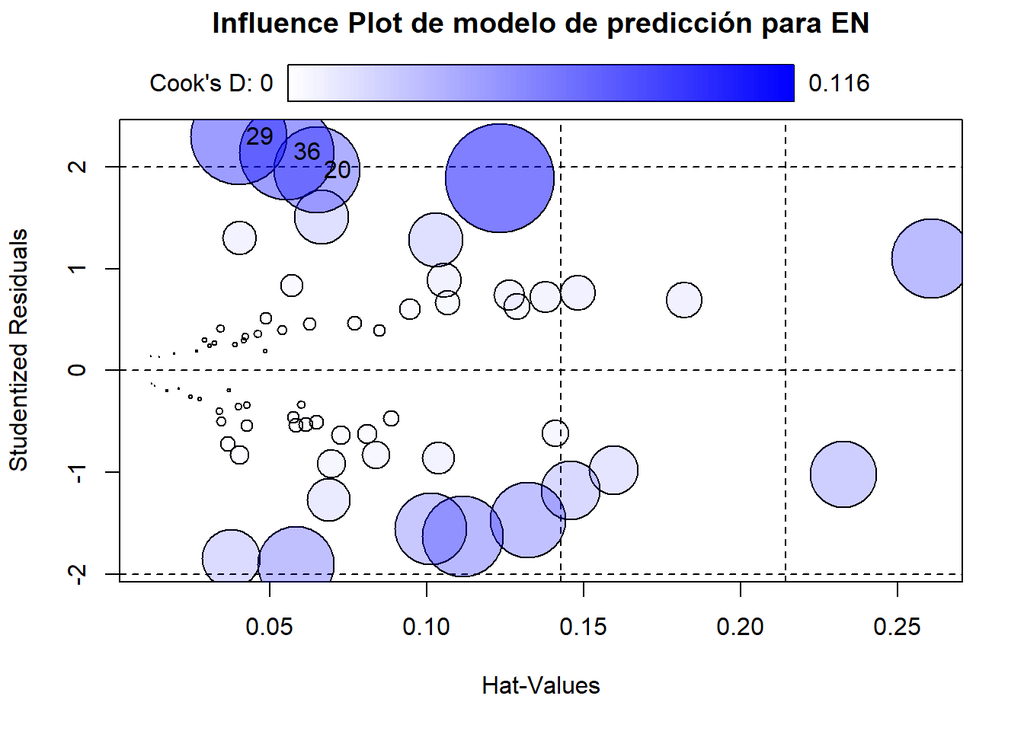

```r
# Añadir el título más arriba
title(main = "Influence Plot de modelo de predicción para EN", line = 3)
```

Se encontraron los 3 valores atípicos que tienen mayor influencia en el modelo. Sin embargo, al observar los valores CookD de estos puntos, se puede ver que no son tan altos como para considerarlos influyentes. Por lo tanto, se decidió que no está justificado el eliminarlos del modelo.

### Poder Predictivo

Se usaron un total de 100 muestras, de las que 70 fueron para entrenamiento del modelo y 30 fueron para pruebas, esta cantidad de muestras nos debería permitir llegar a un modelo confiable.

```r
set.seed(21130)

original_levels <- c("sobrepeso", "no sobrepeso")
valid_levels <- make.names(original_levels)
datos_train <- datos_modelo_3
datos_train$EN <- factor(datos_train$EN, levels = original_levels, labels = valid_levels)

datos_test <- muestra_30
datos_test$EN <- factor(datos_test$EN, levels = original_levels, labels = valid_levels)

# Entrenamiento del modelo con LOOCV
entrenamiento_EN <- train(
  EN ~ .,
  data = datos_train[ , c(predictores_log, "EN")],
  method = "glm",
  family = "binomial",
  trControl = trainControl(method = "LOOCV", classProbs = TRUE, summaryFunction = twoClassSummary),
  metric = "ROC"
)

modelo_EN_final <- entrenamiento_EN[["finalModel"]]

predicciones <- predict(entrenamiento_EN, datos_test)
confusionMatrix(predicciones, datos_test$EN)
```

```
## Confusion Matrix and Statistics
##
##               Reference
## Prediction     sobrepeso no.sobrepeso
##   sobrepeso           12            3
##   no.sobrepeso         3           12
##
##                Accuracy : 0.8
##                  95% CI : (0.6143, 0.9229)
##     No Information Rate : 0.5
##     P-Value [Acc > NIR] : 0.0007155
##
##                   Kappa : 0.6
##
##  Mcnemar's Test P-Value : 1.0000000
##
##             Sensitivity : 0.8
##             Specificity : 0.8
##          Pos Pred Value : 0.8
##          Neg Pred Value : 0.8
##              Prevalence : 0.5
##          Detection Rate : 0.4
##    Detection Prevalence : 0.5
##       Balanced Accuracy : 0.8
##
##        'Positive' Class : sobrepeso
##
```

```r
probs <- predict(entrenamiento_EN, datos_test, type = "prob")[, "sobrepeso"]
roc_test <- roc(response = datos_test$EN, predictor = probs, levels = rev(levels(datos_test$EN)))
```

Usando validación cruzada Leave-One-Out (LOOCV), se entrenó el modelo de regresión logística con las muestras de entrenamiento para predecir el estado nutricional (EN) en las muestras de prueba. Se entrenó para optimizar el área bajo la curva ROC (AUC) y entregó una exactitud, sensibilidad y especificidad de 0.8.

```
## Resumen del modelo final:
```

```
##
## Call:
## NULL
##
## Coefficients:
##                     Estimate Std. Error z value Pr(>|z|)
## (Intercept)          30.4116     8.1042   3.753 0.000175 ***
## Chest.diameter       -0.4286     0.2184  -1.963 0.049675 *
## Ankle.Minimum.Girth  -0.6345     0.4024  -1.577 0.114900
## Forearm.Girth        -0.3967     0.2389  -1.660 0.096819 .
## Ankles.diameter       0.4051     0.5015   0.808 0.419267
## ---
## Signif. codes:  0 '***' 0.001 '**' 0.01 '*' 0.05 '.' 0.1 ' ' 1
##
## (Dispersion parameter for binomial family taken to be 1)
##
##     Null deviance: 97.041  on 69  degrees of freedom
## Residual deviance: 52.782  on 65  degrees of freedom
## AIC: 62.782
##
## Number of Fisher Scoring iterations: 5
```

```
## Valor ROC para el conjunto de entrenamiento:
```

```
##   parameter       ROC      Sens Spec
## 1      none 0.8677551 0.7714286  0.8
```

```
## Valor AUC para predicción usando conjunto de prueba:
```

```
## Area under the curve: 0.8533
```

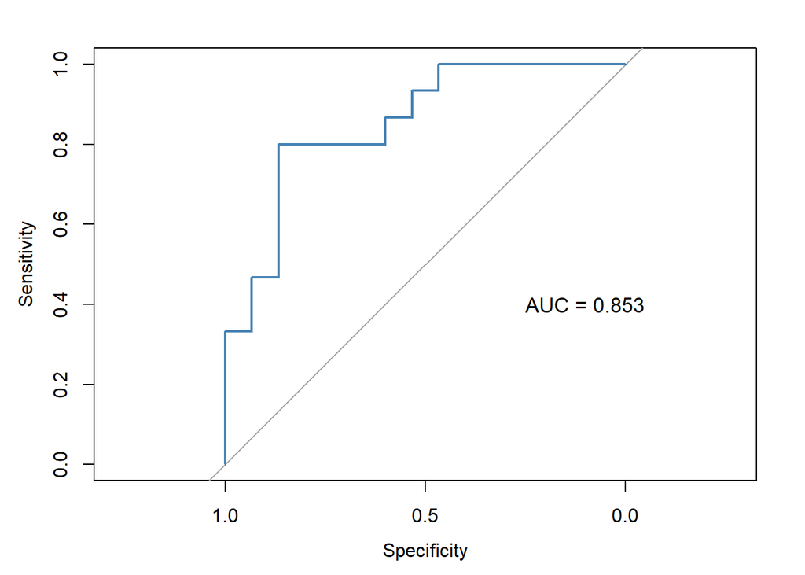

Podemos ver que la devianza se reduce significativamente al agregar los predictores, lo que indica una mejora en el ajuste del modelo. Además, el AUC obtenido por el entrenamiento de 0.8677, indica que el modelo tiene una buena capacidad para discriminar entre las clases “sobrepeso” y “no sobrepeso” y el AUC obtenido en el conjunto de prueba es de 0.853, que no es muy diferente al obtenido en el entrenamiento, por esto, podemos concluir que el modelo tiene una buena capacidad predictiva para datos no vistos.

## Calidad Predictiva

También se evaluará la calidad predictiva utilizando las funciones de la librería pROC para contrastar y complementar el análisis realizado anteriormente. Nuevamente utilizando 70 muestras para entrenar el modelo y 30 muestras para probarlo.

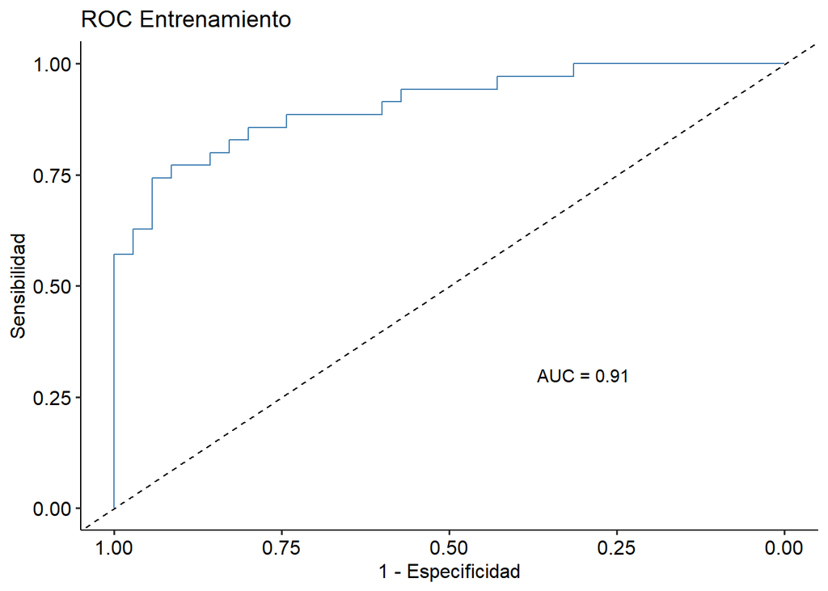

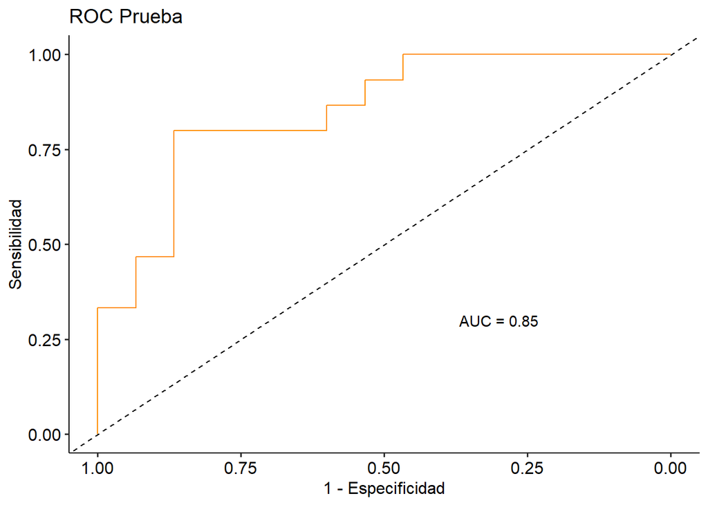

```
##
## Evaluación en conjunto de ENTRENAMIENTO
```

```
##               Reference
## Prediction     no.sobrepeso sobrepeso
##   no.sobrepeso           29         7
##   sobrepeso               6        28
```

```
##
##    Exactitud:     0.814
```

```
##    Sensibilidad:  0.800
```

```
##    Especificidad: 0.829
```

```
##    AUC:           0.908
```

```
##
##
## Evaluación en conjunto de PRUEBA
```

```
##               Reference
## Prediction     no.sobrepeso sobrepeso
##   no.sobrepeso           12         3
##   sobrepeso               3        12
```

```
##
##    Exactitud:     0.800
```

```
##    Sensibilidad:  0.800
```

```
##    Especificidad: 0.800
```

```
##    AUC:           0.853
```

Las métricas de clasificación muestran que el modelo tiene una buena capacidad predictiva, con una alta exactitud, sensibilidad y especificidad en el conjunto de entrenamiento. El AUC de 0.91 indica que el modelo tiene una excelente capacidad para discriminar entre las clases “sobrepeso” y “no sobrepeso”.

# Pregunta 6 (Conclusiones)

Los modelos construidos en este estudio muestran niveles adecuados de confiabilidad y poder predictivo, de acuerdo con las métricas obtenidas en cada caso. La selección rigurosa de variables mediante métodos como la búsqueda exhaustiva (leaps) y la eliminación recursiva de predictores (RFE), junto con estrategias de validación robustas como bootstrapping, validación cruzada por pliegues y validación leave-one-out permitieron minimizar el riesgo de sobreajuste y evaluar de manera más realista el desempeño de los modelos frente a nuevos datos.

Si bien no todos los modelos cumplieron en cada caso con las condiciones para una robusta confiabilidad (como en el modelo de IMC), en general, los modelos obtenidos demuestran un poder predictivo estadísticamente significativo.

Para próximas experiencias se tendrá mayor rigurosidad con los condiciones de confiabilidad y se tendrán en cuenta referencias bibliográficas para una mejor justificación.